# Sapienza Jeremy 1960498 - HW1

Sapienza Jeremy 1960498

5/5/2021

## **Part I**

### *Fully Bayesian conjugate analysis of Rome car accidents*

$$~$$

## Setup

$$~$$

We start to extract the car accident in Rome of the year 2016 contained in a dataframe named *roma*.

```r
mydata <- subset(roma,subset=sign_up_number==104)
y_obs <- mydata$car_accidents # extract the column car_accidents to do the main operations
y_obs; print(paste("The lenght of these observation is: ", length(y_obs), sep=""))
```

```
##  [1] 3 2 4 1 4 8 4 8 3 5 3 2 3 8 3 4 3 2 4
```

```
## [1] "The lenght of these observation is: 19"
```

$$~$$

Using the observed outcomes of the number of car accidents we do a fully Bayesian analysis using as a statistical model a conditionally i.i.d. Poisson distribution $Y_1, ..., Y_n|\theta \sim Poisson(\theta)$ with unknown $\theta$ parameter. In this case we know that the **average number** of hourly car accidents occuring in Rome during the day is **3.22**

$$~$$

## Describing the observed data

$$~$$

Considering the $y_{obs}$ described above, we want to see some interesting features, such as:

```r
print(paste("The mean of the observations is: ", round(mean(y_obs), 3), sep =""))
```

```
## [1] "The mean of the observations is: 3.895"
```

```r
print(paste("The variance of the observations is: ", round(var(y_obs), 3), sep =""))
```

```
## [1] "The variance of the observations is: 4.211"
```

```r
print(paste("The median of the observations is: ", median(y_obs), sep =""))
```

```
## [1] "The median of the observations is: 3"
```

```r
print(paste("The mode of the observations is: ", y_obs[which.max(tabulate(match(y_obs, unique(y_obs))))], sep=""))
```

```
## [1] "The mode of the observations is: 3"
```

$$~$$

The distribution of the data follows this behaviour:

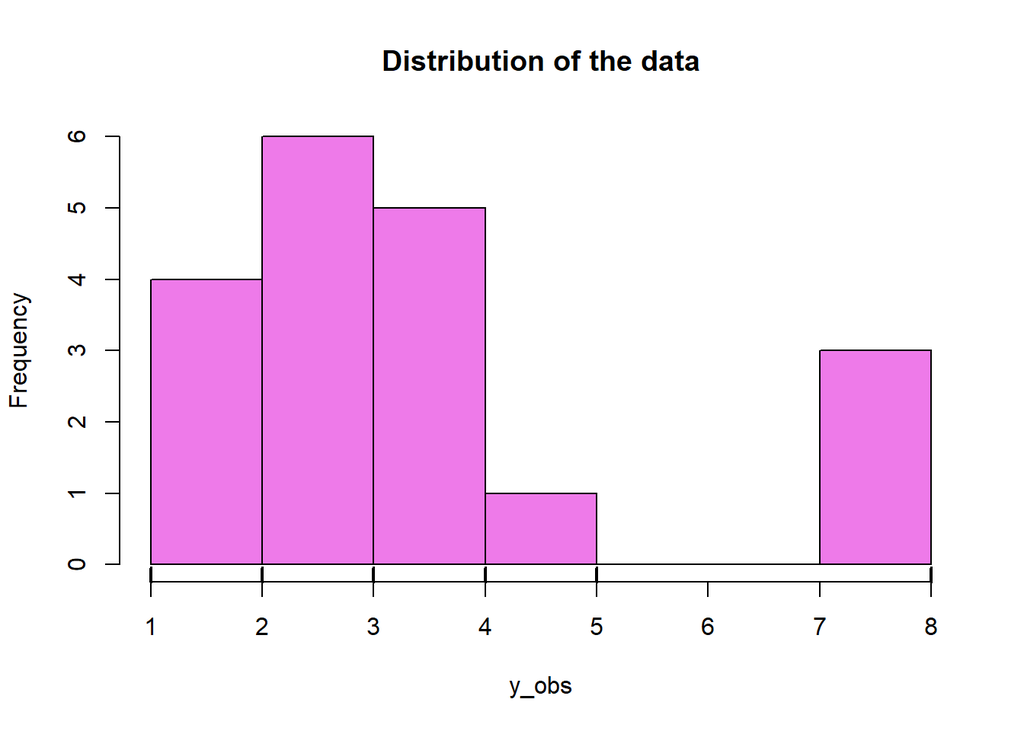

$$~$$

## The ingredients of the Bayesian model

$$~$$

As we know to make an updated version of the parameter of interest is important to set up the Bayesian framework as we can see below:

$$\pi(\theta|y_1, ..., y_n) = \frac{\pi(y_1, ..., y_n|\theta)\pi(\theta)}{\pi(y_1, ..., y_n)}$$

Where:

- $\pi(y_1, ..., y_n|\theta)$ is the likelihood function
- $\pi(\theta)$ is the prior distribution
- $\pi(\theta|y_1, ..., y_n)$ is the posterior distribution

All of these probabilities are based on the $\theta$ parameter, this parameter is the the core of the Bayesian model, whose task is to find it in the best way.

$$~$$

### Likelihood

$$~$$

The likelihood function measures the goodness of fit of a statistical model to a sample of data for given values of the unknown parameter (the number of parameters depends on the statistical model that we use in that moment).

In this case each observation is distributed with the Poisson distribution with $\theta = 3.22$, as we can see below. The joint distribution with n observations follows these steps based on theta parameter:

$$Y_1, ..., Y_n|\theta \sim f(y_1, ..., y_n|\theta) = \prod_{i=1}^{f} (y_i|\theta) = \prod_{i=1}^{n} \frac{e^{-\theta}\theta^{y_i}}{y_i!}$$

In the next steps we consider the likelihood function respect the theta parameter $\propto e^{-n\theta}\theta^{\sum_{i=1}^{n} y_i}$.

Given the theta parameter the likelihood is described differently.

We show some plots to see the different behaviour of the data once a particular theta parameter is given:

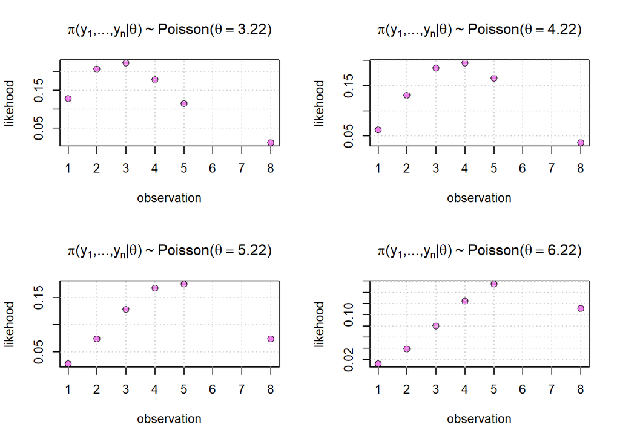

$$~$$

### Prior distribution

$$~$$

Prior distribution is an interesting way to describe our prior information in order to apply this value to the likelihood function and produce the same shape for the posterior distribution. After that, we can know more about of which parameter is good to our data. We can use the conjugacy strategy avoiding integrating the marginal probability on theta, in order to make simple calculus. The conjugacy is a way to see if the shape of two distributions belong to the same family:

Definition of **Conjugate**: *A class $P$ of prior distributions for $\theta$ is called conjugate for a sampling model $p(y|\theta)$ if $p(\theta) \in P \Rightarrow p(\theta|y) \in P$*

In this case the suitable prior distribution leads the posterior within the same family that turns out to be the **Gamma Distribution** family with density:

$$X \sim Gamma(r,s), \,\,\,\,\,\, f(x) = \frac{r^{s}x^{s-1}e^{-rx}}{\Gamma(s)} \mathbb{I}_{(0, +\infty)}(x) \,\,\,\,\, r,s > 0$$

where r is the **rate** and s is the **shape**, so we write the prior as follows:

$$\pi(\theta) = \frac{r^{s}\theta^{s-1}e^{-r\theta}}{\Gamma(s)} \mathbb{I}_{(0, +\infty)} (\theta)$$

To choose the suitable prior parameters r and s, we consider the linear equation on finding the expectation and variance value as follows:

$$\begin{cases}
\mathbb{E}[\theta] = \frac{s}{r} \\
\mathbb{Var}[\theta] = \frac{s}{r^2}
\end{cases}
\rightarrow
\begin{cases}
s = \mathbb{E}[\theta] \cdot r \\
\mathbb{Var}[\theta] = \frac{\mathbb{E}[\theta] \cdot r}{r^2}
\end{cases}
\rightarrow
\begin{cases}
s = \mathbb{E}[\theta] \cdot \frac{\mathbb{E}[\theta]}{\mathbb{Var}[\theta]} \\
r = \frac{\mathbb{E}[\theta]}{\mathbb{Var}[\theta]}
\end{cases}$$

In this case we prefer considering as our prior subjective belief; $s = \mathbb{E}[\theta] \cdot \frac{\mathbb{E}[\theta]}{\mathbb{Var}[\theta]} \approx 1.37$ (where $\mathbb{E}[\theta] = 3.22$ and the $\mathbb{Var}[\theta] = \mathbb{Var}(y_{caraccidents} - y_{obs}) \approx 7.56$) and $r = \frac{\mathbb{E}[\theta]}{\mathbb{Var}[\theta]} \approx 0.42$

Now, we show the prior distribution with its prior shape:

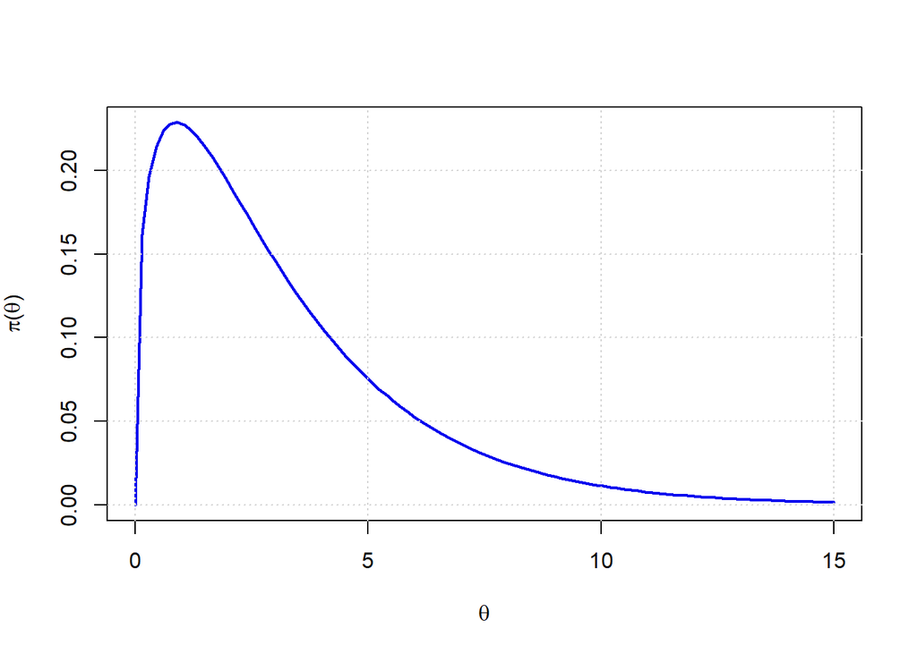

$$~$$

**Note**: The choice of the variance value is given by the history of the portion of data (car_accidents) without the data analyzed in this topic (is cheating, but doesn’t matter for this intial setup of the prior information), this is considering as a good choice of variance, instead of considering a more precise solution like the simulations (that obviously the result is more precise than this one choosen)!

**Note 2**: The shape and the rate calculated before represents the formula of the method of moments for the gamma distribution.

$$~$$

### Posterior update

$$~$$

After defining the main concepts of the prior and likelihood functions, let’s move on the posterior update concept $\pi(\theta|y_1, ..., y_n)$, We apply as we can shown above the conjugancy analysis:

$$\pi(\theta|y_1, ..., y_n) = \frac{\pi(y_1, ..., y_n|\theta)\pi(\theta)}{\pi(y_1, ..., y_n)} \propto \pi(y_1, ..., y_n|\theta)\pi(\theta) \\ =e^{-n\theta}\theta^{\sum_{i=1}^{n} y_i}e^{-r\theta}\theta^{s-1} = e^{-(n+r)\theta}\theta^{(s+\sum_{i=1}^{n} y_i)-1}$$

We avoid the constants in order to see the shape of the posterior distribution. The posterior is also a Gamma distribution and the parameters are:

$$\pi(\theta|y_1, ..., y_n) \sim Gamma\Big(r^* = n + r, \,\,s^* = s+ \sum_{i=1}^{n} y_i\Big)$$

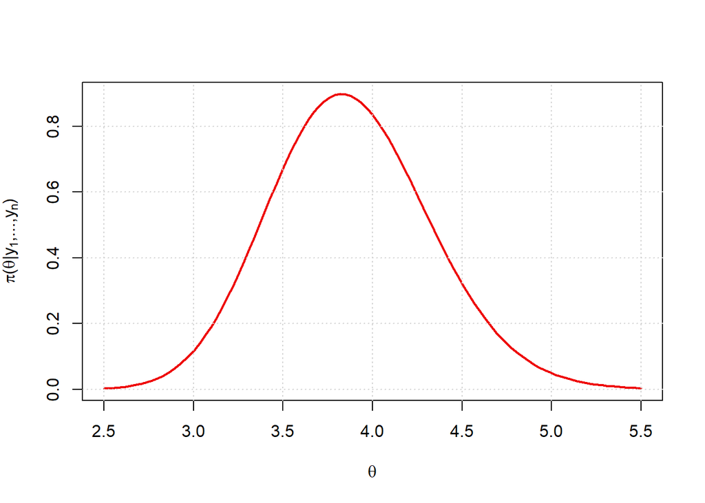

The $\theta$ parameter is updated and fits well the data. the rate and shape parameters are: $r_{post} = 19.42$ and $s_{post} = 75.37$.

$$~$$

# Report the main inferential findings

$$~$$

### Point estimates

$$~$$

All the inferential tasks will be driven by $\pi(\cdot|y^{obs})$ posterior distribution, such as in this case with the point estimates.

We can use the different point estimates to summarize the uncertainty $\theta$ distribution with only one value. The most common summary statistics for posterior distributions are the posterior mean, posterior mode and posterior median, in this case the results are:

$$~$$

- **posterior mode** $\hat{\theta}_{bayes}^{mode}$: represents the higher value of $\theta$ for which we want: $\hat{\theta}_{bayes}^{mo} = \operatorname{argmax}_{\theta \in \Theta} \pi(\theta|y^{obs}) = \frac{s^*-1}{r^*}$

```
## [1] "The posterior mode is equal to: 3.8285"
```

A mode is the most frequent point in a data set. In a Bayesian distribution, this refers to the peak of the distribution.

$$~$$

- **posterior median** $\hat{\theta}_{bayes}^{med}$: represents the $\theta$ value which divides the distribution in half for which:
  $$\hat{\theta}_{bayes}^{med} = {\displaystyle \int_{-\infty}^{\hat{\theta}_{bayes}^{med}}} \pi(\theta|y^{obs}) \,d\theta = {\displaystyle \int_{\hat{\theta}_{bayes}^{med}}}^{+\infty} \pi(\theta|y^{obs}) \,d\theta = \frac{1}{2}$$

```
## [1] "The posterior median is equal to: 3.8628"
```

We consider to find the $\theta$ value which has 50% of the probability to the left and 50% to the right.

$$~$$

- **posterior mean** $\hat{\theta}_{bayes}^{mean}$: represents: $\hat{\theta}_{bayes}^{mean} = \mathbb{E}(\theta|y^{obs}) = \frac{s^*}{r^*}$

```
## [1] "The posterior mean is equal to: 3.8799"
```

The posterior mean is the expected value of the parameter estimate, using the posterior distribution.

$$~$$

Here we can see the point estimates over the posterior uncertainty:

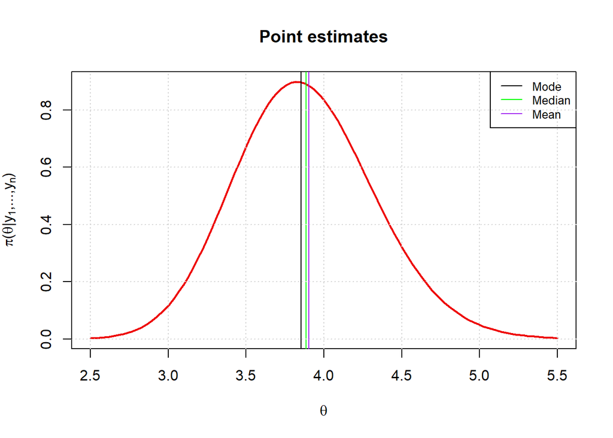

As we known these point estimations are used to measure the central tendency of the posterior distribution, mainly the exact distribution of the posterior is not known and for this reason is necessary to pick a measure that represents with one value the distribution. Typically the proper central tendency is basing on the distribution that we have.

We prefer sometimes to use the posterior mode that is more precise and gives the maximum theta value of our posterior distribution. The median and the mean have typically the same behaviour. Usually also the choice of a point estimate could depend on posterior loss, for a particular decision problem there is the relative point estimate to use, for example:

- if we have a loss function that is an absolute loss, the best estimate is the posterior median
- if we have a loss function that is a quadratic loss, the best estimate is the posterior mean
- if we have a loss function that is an “all-or-nothing” loss, the best estimate is the posterior mode

Basically, the **distribution** that we are analyzing is **asymmetric** given the values just treated are different each other (also even not much).

Another interesting *case* is that sometimes is true that the posterior mode doesn’t give good result, but this is due when the distribution is irregular (depends on the cases).

$$~$$

**Note**: the distribution could be symmetric if all points estimates have the same value, but this isn’t respected. We also know that if the distribution is asymmetric the mean estimates is positioned to the asymmetric diretion. Usually, the asymmetric direction is almost probable to be to the right side, so the mean estimate is larger than the median and/or the mode estimates.

$$~$$

### Posterior uncertainty

$$~$$

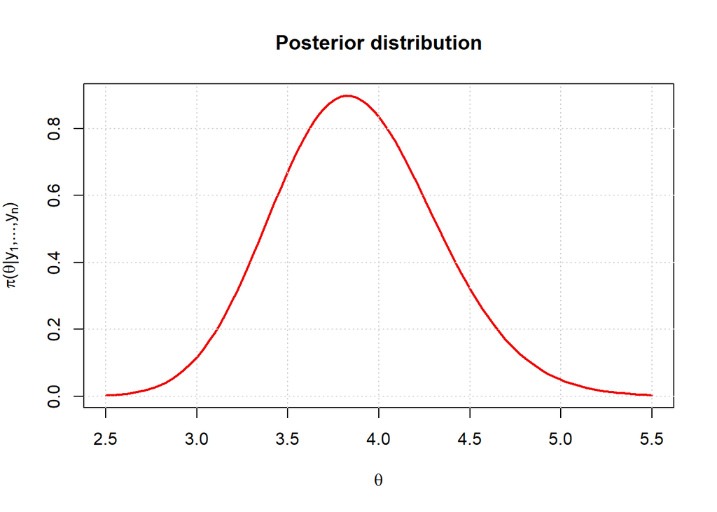

This means that the good $\theta$ parameter tends to be in the interval between 2.5 and 5.5, but for this we will see more in details how to measure this uncertainty.

The uncertainty of the posterior distribution is related to posterior variance of the values in the distribution respect to the posterior mean, as we can seen:

$$~$$

```
## [1] "The posterior mean is: 3.8799"
```

```
## [1] "The posterior variance is: 0.1997"
```

$$~$$

In this case the posterior variance is low. This means that the expected value is consistent.

$$~$$

### Interval Estimates

$$~$$

Often we prefer identifying the region of the parameter space that likely contains the true value of the parameter. After observing the data Y, we construct a credible interval [l(y), u(y)] such that the probability that l(y) < $\theta$ < u(y) is large.

We prefer in this exercise to use the **HPD (Higher posterior density) region**. The HPD has the nice property that any point within the interval has a **higher density** than other point outside, so this interval is the collection of most likely values of the parameters.

The HPD is defined as the 100 x (1-$\alpha$%) of a subset of the parameter space, $s(y) \subset \Theta$ such that:

1. $\pi(\theta \in s(y)|Y=y) = 1 - \alpha$
2. if $\theta_{a} \in s(y)$ and $\theta_{b} \notin s(y)$, then $\pi(\theta_{a}|Y=y) > \pi(\theta_{b}|Y=y)$

As we can see below, there are the values and the range where the hypothetical $\theta$ could is

```
## [1] "The HPD region in this case is between: "
```

```
## [1] 3.022163 4.766821
```

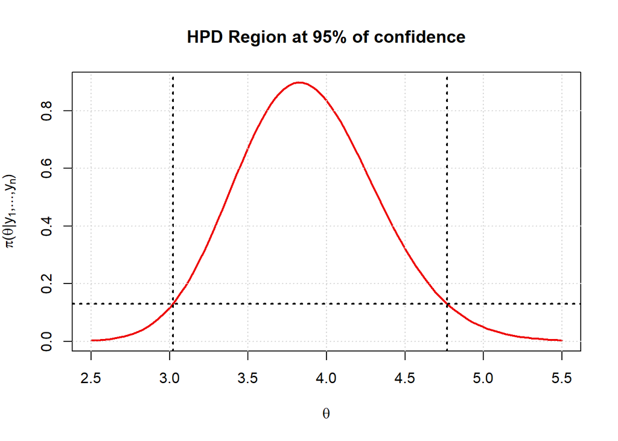

$$~$$

### Difference between the prior and the posterior distribution

$$~$$

The prior distribution incorporates the subjective beliefs about parameters, since a new evidence is introduced. But, sometimes the prior distribution can be *uninformative* or *informative*, if we consider the beta uniform distribution the posterior will be driven entirely by the data (likelihood function).

In this case we have an informative distribution in fact the prior shape tells more about the hyphotetical posterior shape.

The posterior distribution describes in a better way the truth of a data generating process than the prior probability, since the posterior includes more information.

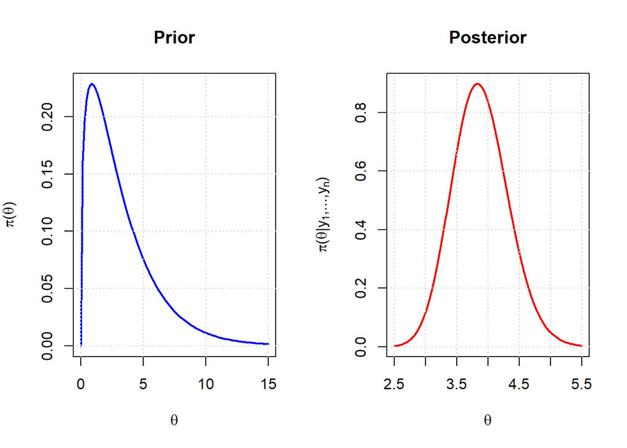

The main difference about the distributions are:

- The parameters that describe each distribution
- The point estimates
- The variance and the mean parameters

and surely other measurement.. As we can see the posterior is slightly different on its direction, after the updated value of the $\theta$ parameter, note that the dashed lines represent the point estimates of the prior distribution:

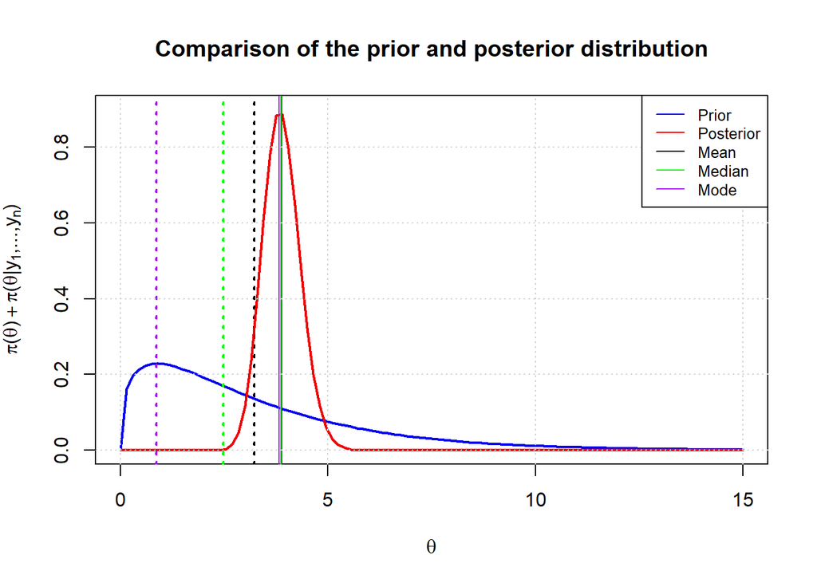

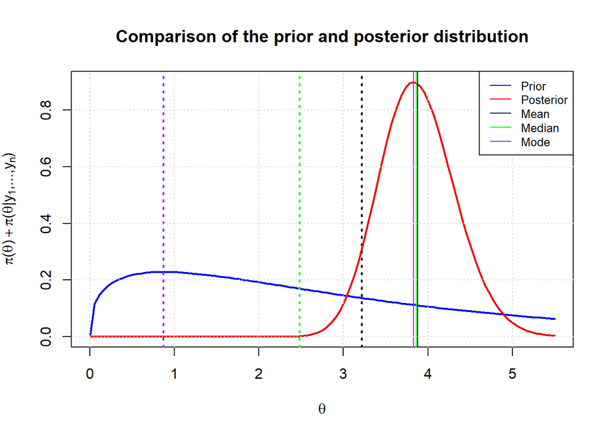

```
## [1] "The prior mean is: 3.22"
```

```
## [1] "The prior variance is: 7.56"
```

```
## [1] "The posterior mean is: 3.8799"
```

```
## [1] "The posterior variance is: 0.1997"
```

$$~$$

### (optional) Provide a formal definition of the posterior predictive distribution of $Y_{next}|y_1, ..., y_n$ and try to compare the posterior predictive distribution for a future observable with the actually observed data

$$~$$

Predictions about other more data are obtained with the posterior predictive distribution, in this subchapter we illustrate with formal steps the posterior predictive distribution for $Y_{next}|y_1, ..., y_n$

Suppose to have:

$$\begin{cases}
Y_{next}, Y|\theta \sim f(y_{next}, y|\theta) = f(y_{next}|\theta) f(y|\theta) \\
\theta \sim Gamma(r, s)
\end{cases}$$

where $Y_{next}$ and $Y$ are conditional independent wrt $\theta$ and $f(y_{next}, y|\theta) \sim Poisson(\theta)$ Given a observation $Y = y$ we find what is $Y_{next}$ conditioned on $y$, that means:

$$Y_{next}|y \sim \frac{J(y_{next}, y)}{J(y)} = m(y_{next}, y)$$

this is called as (conditional) posterior predictive, we are interested to have:

$$m(y_{next}|y) \propto J(y_{next}, y)$$

Working on the joint, we have:

$$J(y_{next}, y) = {\displaystyle \int_{\Theta} J(y_{next}, y, \theta) \,d\theta} \\
= {\displaystyle \int_{\Theta} J(y_{next}|\theta) J(y|\theta) \pi(\theta) \,d\theta} \\
\propto {\displaystyle \int_{\Theta} f(y_{next}|\theta) \frac{f(y|\theta)\pi(\theta)}{m(y)} \,d\theta} \\
= {\displaystyle \int_{\Theta} f(y_{next}|\theta) \pi(\theta|y) \,d\theta} \\$$

for the density of Y we get:

$$J(y) = \int_{\mathcal{Y}} \int_{\Theta} J(y_{next}, y, \theta) \,dy_{next}d\theta \\
= \int_{\mathcal{Y}} \int_{\Theta} f(y_{next}|\theta) f(y|\theta) \pi(\theta) \,dy_{next}d\theta \\
= \int_{\Theta} f(y|\theta) \Bigg(\int_{\mathcal{Y}} f(y_{next}|\theta) \pi(\theta) \,dy_{next} \Bigg) d\theta \\
= \int_{\Theta} f(y|\theta) \pi(\theta) d\theta = m(y)$$

For predicting a new Gamma observation $Y_{next}$ after observing a $Y = y$ observation we can use the $m(y_{next}|y)$ and we have the **Negative Binomial Distribution** as follows:

$$Y_{next}|y \sim NegBin \Bigg( p = \frac{r_{prior}+n}{r_{prior}+n+1}, m = s_{prior} + \sum_{i=1}^{n} y_i\Bigg)$$

below is shown a simple code to illustrate this kind of posterior prediction based on the y_obs:

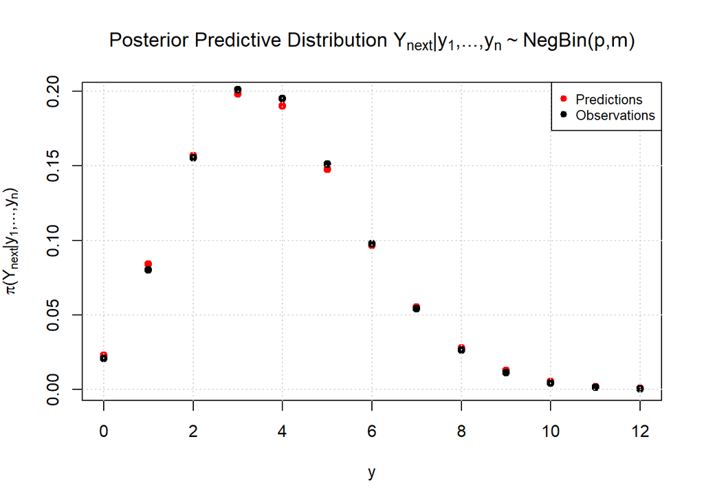

$$~$$

Considering the actual data, the behaviour is:

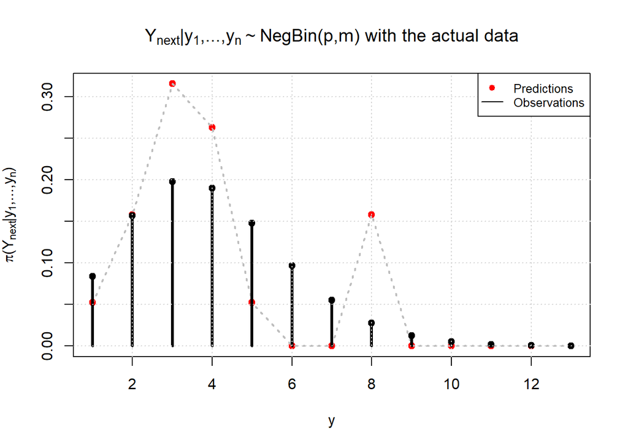

$$~$$

## **Part II**

### *Bulb lifetime*

$$~$$

## Setup

$$~$$

For this setting imagine there are innovative bulbs and the goal is to characterize them statistically. We consider 20 innovative bulbs to determine their lifetimes, I observe the follwing data expressed in terms of hours:

```
##  [1]    1   13   27   43   73   75  154  196  220  297  344  610  734  783  796
## [16]  845  859  992 1066 1471
```

```
##    Min. 1st Qu.  Median    Mean 3rd Qu.    Max.
##     1.0    74.5   320.5   479.9   808.2  1471.0
```

$$~$$

The distribution of these data is:

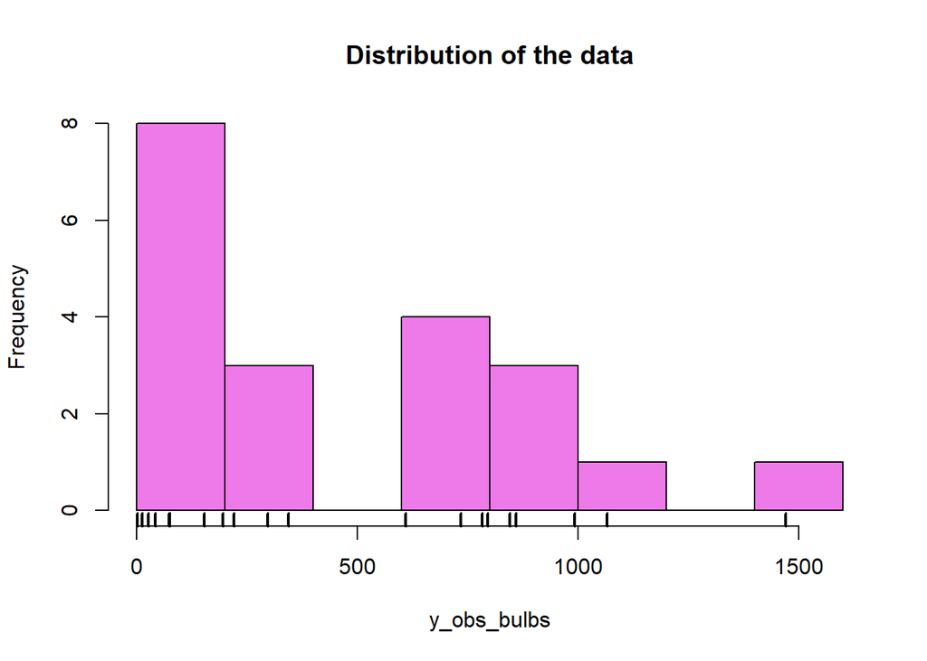

Based on the experience with light bulbs, These observations $Y_i$ described their lifetimes using an **exponential distribution** conditionally on $\theta$, the likelihood function is written in this way:

$$f(y_1, ..., y_n|\theta) \sim Exponential(\theta)\\
Y_1, ..., Y_n|\theta \sim f(y_1, ..., y_n|\theta) = \prod_{i=1}^{f} (y_i|\theta) = \prod_{i=1}^{n} \theta e^{\theta y_i} = \theta^{n}e^{-\theta \sum_{i=1}^{n} y_i}$$

$$~$$

## The ingredients of the Bayesian model

$$~$$

As we described in the first part of this homework, we are interested to calculate the posterior distribution in order to update well the parameter of interest. Now, we are focussing on the choice of the suitable prior distribution.

For this exercise in order to choose a suitable prior distribution $\pi(\theta)$ we decide to pick the Gamma distribution to be able to apply the conjugate analysis:

$$\pi(\theta) = \frac{r^{s}\theta^{s-1}e^{-r\theta}}{\Gamma(s)} \mathbb{I}_{(0, +\infty)} (\theta) \\
where \,\,\, \mathbb{E}[\theta] = 0.003 \,\,\, and \,\,\, \mathbb{V}[\theta] = (0.00173)^2 and \,\, r,s > 0$$

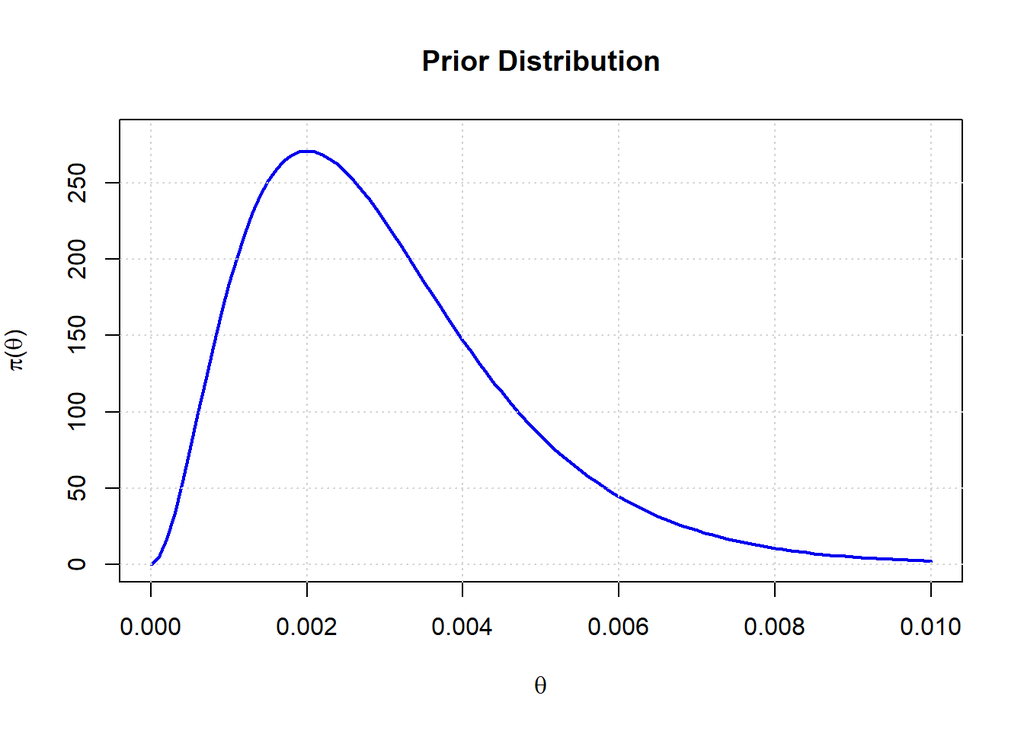

$$~$$

The vague prior opinion is that the standard deviation is high, this means that the mean of the values is unstable and the dispersion of the values is high. Considering the ratio $\frac {sd[\theta]}{E[\theta]} \approx 57\%$.

Is important to denote that reparametrizing the prior parameters of the gamma distribution and working on the posterior mean, the posterior mean is a convex combination of the prior mean and the sample mean and for this reason the standard deviation is related to the mean of the values.

$$~$$

### Conjugate Bayesian analysis

$$~$$

Initially, we need to fix the values of the prior parameters (rate and shape) of the gamma distribution:

$$\begin{cases}
\mathbb{E}[\theta] = \frac{s}{r} \\
(\mathbb{Var}[\theta])^2 = \frac{s}{r^2}
\end{cases}
\rightarrow
\begin{cases}
s = \mathbb{E}[\theta] \cdot r \\
(\mathbb{Var}[\theta])^2 = \frac{\mathbb{E}[\theta] \cdot r}{r^2}
\end{cases}
\rightarrow
\begin{cases}
s = \mathbb{E}[\theta] \cdot \frac{\mathbb{E}[\theta]}{(\mathbb{Var}[\theta])^2} \\
r = \frac{\mathbb{E}[\theta]}{(\mathbb{Var}[\theta])^2}
\end{cases}
\rightarrow
\begin{cases}
s \approx 3.007 \\
r \approx 1002.37
\end{cases}$$

At the end, the parameters for the prior distribution are $\pi(\theta) \sim Gamma \Big(r = 1002.37, s = 3.007 \Big)$

Having now the prior parameters is possible to calculate and find the posterior parameters (as we can seen in the first part of the homework), this means:

$$\pi(\theta|y_1, ..., y_n) = \frac{\pi(y_1, ..., y_n|\theta)\pi(\theta)}{\pi(y_1, ..., y_n)} \propto \pi(y_1, ..., y_n|\theta)\pi(\theta) = \\
= \theta^{n}e^{-\theta \sum_{i=1}^{n} y_i} \cdot \theta^{s-1} e^{-r\theta} = \theta^{(s+n)-1}e^{-\theta(r+\sum_{i=1}^{n} y_i)}$$

The posterior parameters of the gamma posterior distribution are:

$$\pi(\theta|y_1, ..., y_n) \sim Gamma\Big(r^* = r + \sum_{i=1}^{n} y_i, \,\, s^* = s + n\Big)$$

The shapes of the prior and the posterior follow this behaviour:

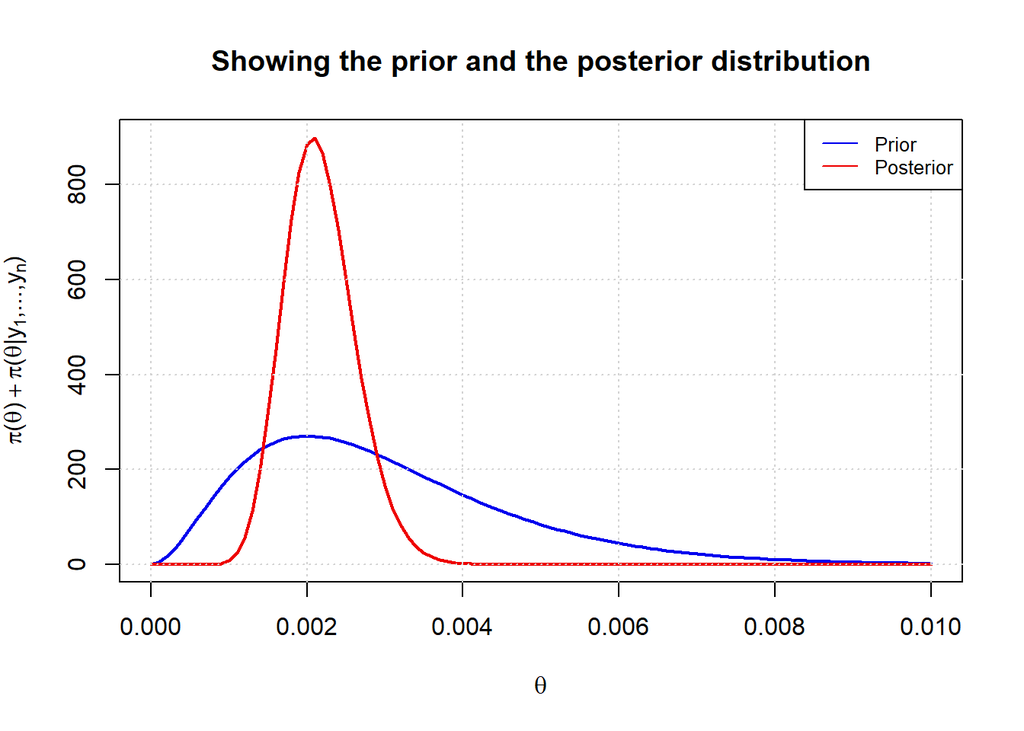

$$~$$

## Commenting on the characteristics of the lifetime of these innovative bulbs

$$~$$

To be more sure about the lifetime of a bulb, we can make suitable analysis considering the point estimates to see well which is the hypothetical $\theta$ parameter and later makes also the HPD interval to see where the theta parameter fall.

We see different point estimates used in the first part of the homework:

$$~$$

- **posterior mode** $\hat{\theta}_{bayes}^{mode}$: represents the higher value of $\theta$ for which we want: $\hat{\theta}_{bayes}^{mo} = \operatorname{argmax}_{\theta \in \Theta} \pi(\theta|y^{obs}) = \frac{s^*-1}{r^*}$

```
## [1] "The posterior mode is equal to: 0.0021"
```

$$~$$

- **posterior median** $\hat{\theta}_{bayes}^{med}$: represents the $\theta$ value which divides the distribution in half for which:
  $$\hat{\theta}_{bayes}^{med} = {\displaystyle \int_{-\infty}^{\hat{\theta}_{bayes}^{med}}} \pi(\theta|y^{obs}) \,d\theta = {\displaystyle \int_{\hat{\theta}_{bayes}^{med}}}^{+\infty} \pi(\theta|y^{obs}) \,d\theta = \frac{1}{2}$$

```
## [1] "The posterior median is equal to: 0.0021"
```

$$~$$

- **posterior mean** $\hat{\theta}_{bayes}^{mean}$: represents: $\hat{\theta}_{bayes}^{mean} = \mathbb{E}(\theta|y^{obs}) = \frac{s^*}{r^*}$

```
## [1] "The posterior mean is equal to: 0.0022"
```

$$~$$

Here we can see the point estimates and the HPD region over the posterior uncertainty:

```
## [1] "The actual region of the HPD region is: "
```

```
## [1] 0.001322506 0.003072165
```

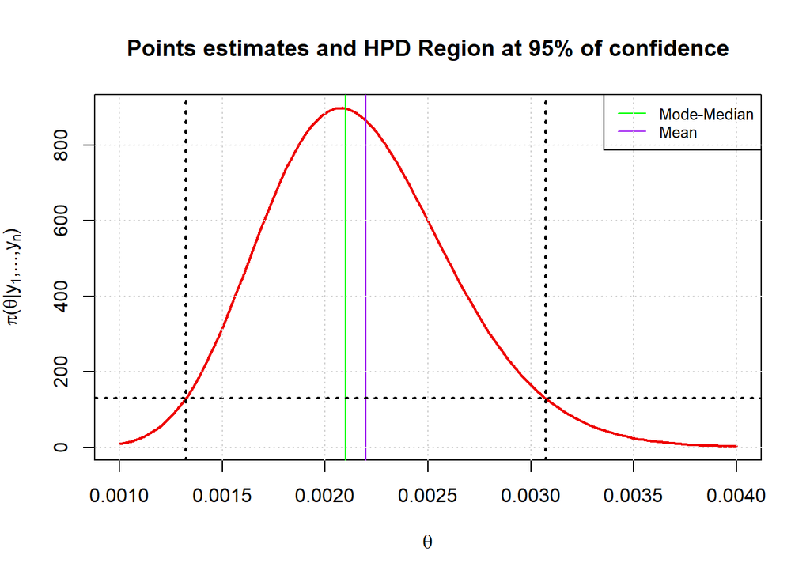

As we can see the actual $\theta$ is probably equal to 0.002, the results shown by the point estimates are similar considering only the mode and the median, however the posterior distribution is **asymmetric**, for having the symmetric distribution all of the three point estimates must have the same value and this isn’t respected.

Instead, considering the reparametrization of $\theta$ in $\psi = \frac{1}{\theta}$ we maybe say something interesting, let’s do it:

- **posterior mode** $\hat{\psi}_{bayes}^{mode} = \frac{1}{\hat{\theta}_{bayes}^{mode}}$

```
## [1] "The posterior mode is equal to: 481.7247"
```

- **posterior median** $\hat{\psi}_{bayes}^{med} = \frac{1}{\hat{\theta}_{bayes}^{med}}$

```
## [1] "The posterior median is equal to: 467.5428"
```

- **posterior mean** $\hat{\psi}_{bayes}^{mean} = \frac{1}{\hat{\theta}_{bayes}^{mean}}$

```
## [1] "The posterior mean is equal to: 460.7866"
```

$$~$$

With these amazing results, the procedures in this moment are consistent. The $\theta$ parameter should be correct, also because we have the posterior mean that is almost equal to the true mean of these observations!

$$~$$

## Answering to Boss’ request

$$~$$

Recalling that the posterior distribution is a gamma distribution, to answer to Boss’ request is needed to setup a simple procedure in order to get the probability that the average bulb lifetime is $\psi = \frac{1}{\theta}$ and $Y = y_1,...,y_n$:

$$P(\psi > 550 | Y) = P\Big(\frac{1}{\theta} > 550 \Big| Y\Big) = P\Big(\theta < \frac{1}{550} \Big| Y\Big)$$

Considering the posterior theta parameters, the probability to have the bulb lifetime over 550 is:

```r
pgamma(1/550, shape = s_post, rate = r_post)
```

```
## [1] 0.2254117
```

$$~$$

The probability achieved from the previous calculus says that only 22% of bulbs have a lifetime that exceeds over 550 hours. With these calculus is simple to note that considering the bayesian parameters calculated with the conjugate analysis the result achieved is consistent, given the posterior parameters.